# Git for version control

# Some motivating examples

- While working on your analysis code, you accidentally erase the first 35 lines of the script. You only discover this three days later, when you restart R and try to run the script from the top.
- The code you wrote last week is suddenly giving you different results. A bunch of variables are missing, and the standard errors are huge. When you’re talking with your collaborator, he says that he was cleaning the data a few days ago and everything seemed fine. When you go to check, you discover that he’s replaced your 827 survey responses with 6 group summaries.

You’re working on a paper with two coauthors. You prepare the final draft to send for submission: `paper final.docx`. But one of your coauthors discovers a typo. Now it’s `paper final fixed typo.docx`. Another realizes six references are missing. `paper final fixed typo refs.docx`. That’s getting confusing so you change it to `paper 2 Aug 2021.docx`. Once it comes back from review you need to make revisions. Now you have `paper 30 Jan 2022.docx` and, after your collaborators make their changes, `paper 12 February 2022 DJH.docx` and `paper 12 February 20222 final.docx`.

# Version control

- Basic idea: Tools for tracking and reversing changes to code over time
- Useful for identifying and reversing breaking changes
- Implementations upload to cloud, track who contributes code, control who can suggest vs. actually change code
- Good for collaboration, publishing code

# Git

- One of many version control systems
- Very popular in part thanks to GitHub, which provides free hosting git repositories
  - Resources for students (and teachers): https://education.github.com/

# Gitting started

- [git is very hard](https://www.google.com/search?q=git+is+too+complicated)
- We’re going to use the [Sourcetree GUI](https://www.sourcetreeapp.com/) to ease into things

# Initial commit

[figure not shown]

Creating a new local repository in `learning-git`

- Install Sourcetree and go through the configuration steps
- Then you’ll see the (empty) repository browser
- Create a folder called something like `learning-git`
- Then, in Sourcetree:
  - On the Local tab
  - Select New … > Create a local repository (or) Drag and drop the folder on to the browser
- You can open the repository in Sourcetree, but it’s not interesting yet
- In `learning-git`, create a text file, eg, `testing.txt`
- Sourcetree’s File Status panel shows the new file, ready to be tracked

# Tracking changes

[figure not shown]

Making your initial commit

- Tracking changes to a file involves two steps: **Adding** and **committing**
- **Add**: Click the checkmark
  - This tells git that we want to store these changes to the file in its archive
- **Commit**: Type a message in the comment field and click Commit
  - This tells git to go ahead and do the archiving process
- The commit is now displayed in the History panel

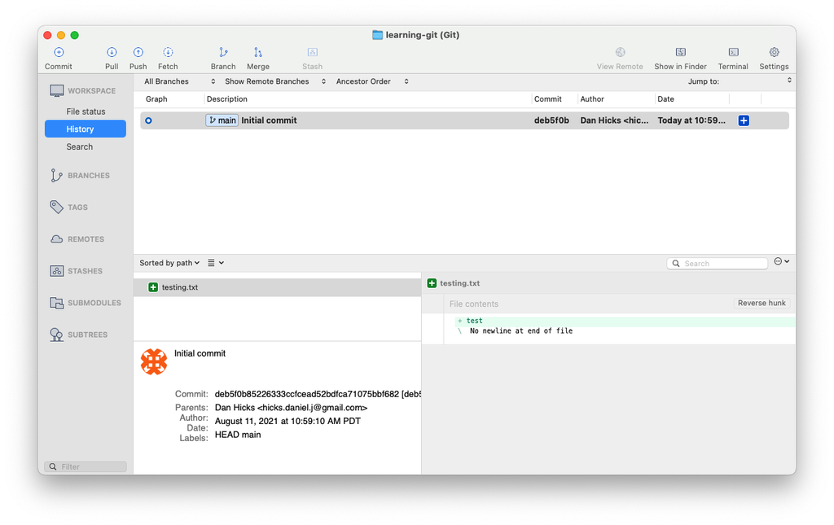

The History panel after our first commit

*Make a few more changes to the file. Practice adding and committing them and note how the changes accumulate in the History panel.*

# Time travel

- We can **checkout** previous commits to work with old versions of our files
- In the example, suppose I made a commit with a mistake (my code stopped working or whatever)
- In the History panel, right-click on a previous commit and select Checkout…

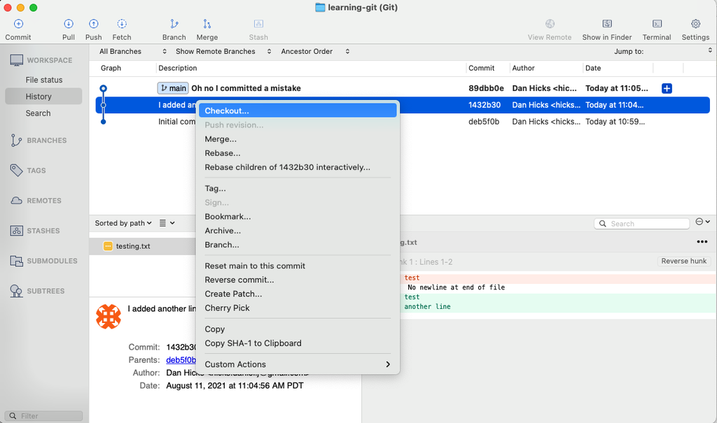

Checking out an old commit to travel through time

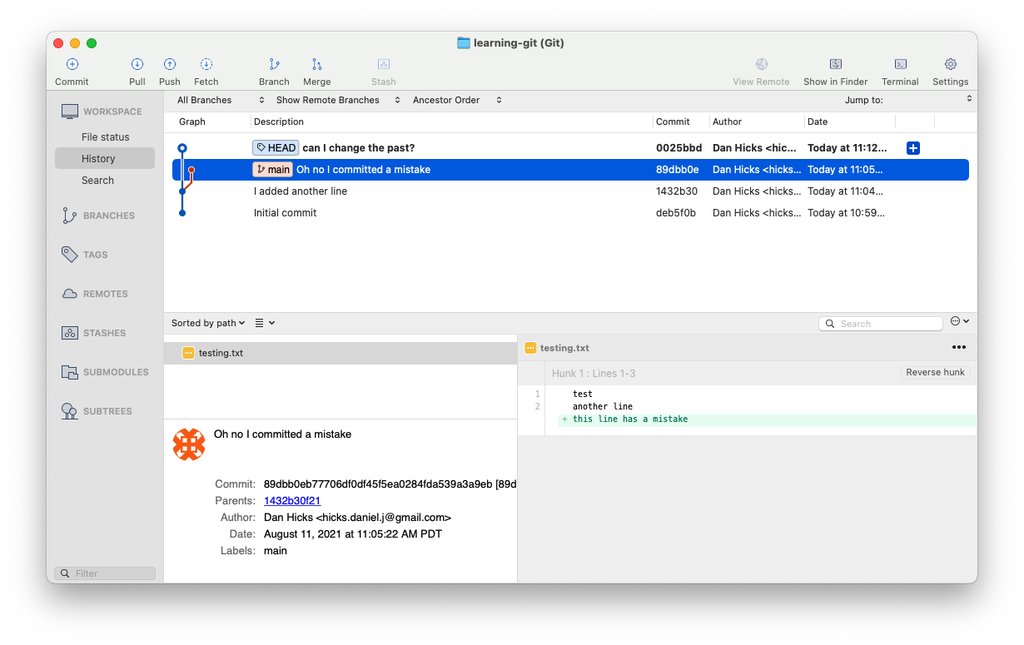

Trying (and failing) to change the past. My current HEAD commit will disappear as soon as I check out main.

# The garden of forking branches

- To actually change the past, we’ll use a **branch**
  - Branches allow git to track multiple distinct “timelines” for files
  - For example, most major software projects will have separate “dev” (development) and “release” branches
  - Individual branches will also be created for work on specific areas of the project
  - This allows each area of active work to be isolated from work happening in other areas

[figure not shown]

Merging `fixing-mistake` into `main`

- After checking out the previous commit, click on Branch in the toolbar
  - Name your new branch something like `fixing-mistake` (no spaces!)
- Start to work on fixing the mistake in the file, then add and commit as usual
- Now checkout `main`. Notice:
  - Your commits on `fixing-mistake` don’t disappear
  - The state of your file changes to the `main` version
  - The History panel shows the split between the two branches
- After we’ve finished fixing the mistake, we want to **merge** these changes back into `main`
  - Make sure you’re current on `main`
  - Right-click on `fixing-mistake` and select Merge…
- Sourcetree will bring up a message about **Merge Conflicts**
  - This just means that the files you’re combining have conflicting histories, and git wants you to sort out what to keep and what to throw away

It’s not obvious (there isn’t a big red status symbol anywhere), but git is now in a special conflict-resolution state.

Until you resolve the conflicts and finish the merge, a lot of standard git functionality either won’t work at all or will cause weird problems.

**If git starts giving you a bunch of weird errors, check to see if you’re in the middle of a merge and need to resolve conflicts.**

[figure not shown]

Sourcetree’s File status panel indicates which files have conflicts

After starting the merge, Sourcetree’s File status panel will indicate exactly which files have conflicts.

Your file will look something like this

```
test
another line
<<<<<<< HEAD
this line has a mistake
=======
no mistake this time
>>>>>>> fixing-mistake
```

- The `<<<<<<<` and `>>>>>>>` surround each area of conflict.
  - The top part (marked `HEAD`) shows the state of the current branch
  - The bottom part (marked `fixing-mistake`) shows the state of the branch you’re merging
- Simply edit these sections so they’re in the state you want,
  - Then save, go back to Sourcetree’s File status panel
  - Sourcetree generates a commit message indicating that you’re resolving conflicts to complete a merge

Afterwards the History panel shows the two branches merging back together

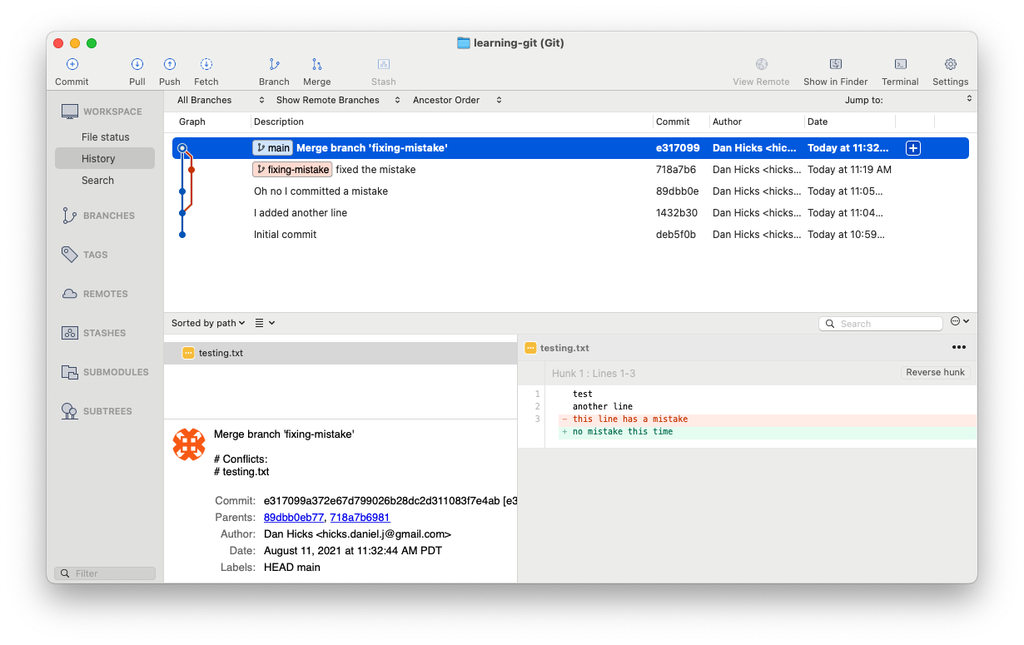

The History panel shows the branches merging back together

# Authenticating Sourcetree with GitHub

1. Make sure you’re logged in to GitHub in your default web browser
2. In Sourcetree
   - Go to a New Tab
   - Then Remote (just underneath the tabs)
   - Add an account …
   - Hosting Service: GitHub  
     Authentication: OAuth  
     Username: [shouldn’t be able to enter anything]
   - Click “Refresh OAuth Token”
3. Focus should switch to a new tab in your web browser
   - Scroll down and click “Authorize atlassian” green button
4. Browser should now say “Authentication Successful” and GitHub should send you a security notice via email
5. Back in Sourcetree, click okay

# Working with GitHub remotes

[figure not shown]

The remote `origin` lives on GitHub. Source: https://happygitwithr.com/common-remote-setups.html#ours-you

A **remote** is a copy of a repository that lives on a server somewhere else

# Working with your own repos

- On GitHub, click “New” and walk through the steps to create a new repository
  - The name on GitHub doesn’t need to match the local name
  - But why wouldn’t you use the same name?
- Copy the URL: `https://github.com/[username]/learning-git`
- Back in Sourcetree
  1. Go to Settings in the toolbar
  2. Go to the Remotes tab
  3. Click Add to add a new remote
- The standard name for a default remote is `origin`
  - Paste in the GitHub URL

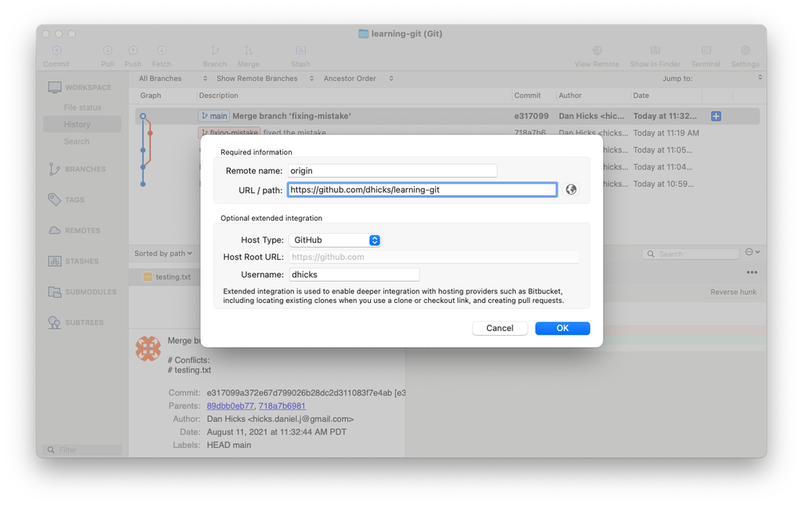

Adding a new remote

- After adding the remote, we can send the repository (including its full history) up to GitHub using **push**
  - Look for Push in the toolbar
  - Sourcetree will ask which branches to push
- When the push is complete, refresh GitHub in your browser
  - You can edit files directly in GitHub
- Now we’ll **fetch** and **pull** the changes from GitHub back to our local copy
  - **Fetch**: Compare the local tree to the remote tree, noting any differences. Use this to preview the changes on the remote
  - In Sourcetree, hit Fetch in the toolbar. Note that the GitHub commit shows up in the History panel.
  - **Pull**: Actually download the remote changes and incorporate them into your local tree.

# Lab: Working with *someone else’s* repos

- GitHub lets you download someone else’s repo (**clone**), and modify it locally, but *not* upload directly.
- You can suggest a change to someone else’s code by submitting a **pull request**, which first requires **forking** the repository.

[figure not shown]

*Forking* copies a repository to your GitHub account. Then you *clone* the copy to your local machine. You can *push* to your remote copy as usual. You can suggest changes to the original using a *pull request*. Source: https://happygitwithr.com/fork-and-clone.html

- Start with the repo for this week’s lab: https://github.com/data-science-methods/lab-w02-git
- **Fork**: Look for the `fork` button in the upper-right

[figure not shown]

The *fork* button is near the upper-right corner of a GitHub repository page. I wasn’t able to find a keyboard shortcut for this. :-(

- **Clone**: After creating the fork, you need to download a copy to your machine.
  - In Sourcetree’s repository browser, select New… > Clone from URL
- This lesson continues in the lab. Open `lab.html` and `lab.Rmd` to continue.